# Trends in Maternal Mortality in Nigeria: 1990-2015

A call for action

Balogun Stephen Taiye

Balogun Kehinde Ayantunde

08 September 2016

# Introduction

Maternal death is defined as *the death of a woman, while pregnant or within 42 days of termination of pregnancy, irrespective of the duration and site of pregnancy, from any cause related to or aggravated by pregnancy, but not from accidental or incidental causes*.<sup>[[1]](http://apps.who.int/iris/bitstream/10665/70929/1/9789241548458_eng.pdf)</sup> Maternal Mortality Ratio (MMR), on the other hand, is *the number of deaths due to “maternal causes” in a given community/country, in a year per 100 000 live births in the same year in the same community/country*.<sup>[[2]](http://apps.who.int/iris/bitstream/10665/194254/1/9789241565141_eng.pdf)</sup> It is a very sensitive indicator of the health status of women in the reproductive age group, as well as of the obstetric services. It should be noted however that MMR does not include the near death experiences and several other morbidities that could happen in the period of pregnancy, labour and delivery, and the postpartum period. These morbidities are perhaps multiples of mortalities.

Ideally, *“no woman should lose her life in the process of making another”*. Unfortunately, the reality is far from ideal and can only be a target one dreams to achieve. Close to half a million women die each year due to complications during pregnancy and birth.<sup>[[2]](http://apps.who.int/iris/bitstream/10665/194254/1/9789241565141_eng.pdf)</sup> The vast majority of these deaths are preventable. In this regard, the United Nations (UN) Member States came together in the year 2000 and pledge towards a series of Millennium Development Goals **(MDGs)**, including the target of a *three-quarters reduction in the 1990 maternal mortality ratio (MMR) to be achieved by the year 2015* **(MDG 5A)**.<sup>[[3]](http://www.un.org/millenniumgoals/maternal.shtml)</sup> Currently, the world is building on the momentum generated by the MDGs, Sustainable Development Goals **(SDGs)**, to establish a transformative new agenda towards ending preventable maternal mortality. *The target 3.1 of SDG 3 is to reduce the global MMR to less than 70 per 100 000 live births by 2030*.<sup>[[4]](http://www.un.org/sustainabledevelopment/health/)</sup>

Globally, the MMR fell by nearly 44% between 1990 and 2015, from an estimated MMR of 385 to an MMR of 216.<sup>[[2]](http://apps.who.int/iris/bitstream/10665/194254/1/9789241565141_eng.pdf)</sup> There was also a reduction in the annual number of maternal deaths by 43% from approximately 532 000 in 1990 to an estimated value of 303 000 in 2015.<sup>[[2]](http://apps.who.int/iris/bitstream/10665/194254/1/9789241565141_eng.pdf)</sup> However, developing countries account for 99% of the global maternal deaths in 2015, with sub-Saharan Africa alone accounting for roughly two-thirds.<sup>[[2]](http://apps.who.int/iris/bitstream/10665/194254/1/9789241565141_eng.pdf)</sup> Nine countries that had MMR of more than 100 in 1990 were able to achieve MDG 5A based on MMR reduction point-estimates including a reduction of at least 75% between 1990 and 2015: Bhutan, Cambodia, Cabo Verde the Islamic Republic of Iran, the Lao People’s Democratic Republic, Maldives, Mongolia, Rwanda and Timor-Leste.<sup>[[2]](http://apps.who.int/iris/bitstream/10665/194254/1/9789241565141_eng.pdf)</sup> To achieve the SDG target of a global MMR below 70, it will require reducing global MMR by an average of 7.5% each year between 2016 and 2030, a value 3 times more than the 2.3% annual rate of reduction observed during the MDG years.<sup>[[2]](http://apps.who.int/iris/bitstream/10665/194254/1/9789241565141_eng.pdf)</sup>

In 1990, Nigeria was estimated to have a maternal mortality ratio of 1350, this value declined to 814 in the year 2015.<sup>[[2]](http://apps.who.int/iris/bitstream/10665/194254/1/9789241565141_eng.pdf)</sup> Despite this reduction however, Nigeria was adjudged to have made **“no progress”** towards achieving the MDG 5A goal according to the WHO, UNICEF, UNFPA, World Bank Group and the UNFPA [Trends in Maternal Mortality:1990 to 2015](http://apps.who.int/iris/bitstream/10665/194254/1/9789241565141_eng.pdf) report. At a glance, one would argue that a change from an MMR of 1350 to 814 represents a reduction of MMR by 536, this appears to be a significant change. Why then would over one-third reduction in MMR be classified as “no progress”? Hopefully, you will be able to understand this by the time you finish reading this article.

# Brief Statistics of Nigeria

Nigeria is an African country located in the sub-Saharan sub-region. It is on latitude 6<sup>o</sup>27’N and longitude 3<sup>o</sup>23’E.<sup>[[5]](https://en.wikipedia.org/wiki/Nigeria)</sup> It is comprised of 36 states and the Federal Capital Territory, Abuja.<sup>[[6]](http://www.nigerianstat.gov.ng/)</sup> With approximately 187 million inhabitants, it is the most populous country in Africa and the seventh most populous country in the world.<sup>[[5]](https://en.wikipedia.org/wiki/Nigeria)[[7]](http://data.un.org/CountryProfile.aspx?crName=NIGERIA)</sup> It accounts for approximately one sixth of the African population and one fifth of the sub-Saharan African population.<sup>[[5]](https://en.wikipedia.org/wiki/Nigeria)</sup>

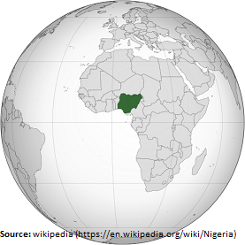

Nigeria has one of the largest youth populations in the world with age-group 15-64 accounting for about half of the population.<sup>[[5]](https://en.wikipedia.org/wiki/Nigeria)</sup> Its reproductive age-group (women aged 15-49) is ranked the 7th largest in the world with a population size of about 41 million.<sup>[[7]](http://data.un.org/CountryProfile.aspx?crName=NIGERIA)</sup> It has a median population age of 18years, and a Total Dependency Ratio (population aged 0-14 years & 65+ per 100 of population 15-64 years) of 88.<sup>[[7]](http://data.un.org/CountryProfile.aspx?crName=NIGERIA)</sup> In 2014, Nigeria was estimated to have a Total Fertility Rate of 5.7, an annual growth rate of 2.7%, and a life expectancy at birth of 52.6/52.0 years for females and males respectively.<sup>[[7]](http://data.un.org/CountryProfile.aspx?crName=NIGERIA)</sup>

Nigeria recently emerged as Africa’s largest economy with a Gross domestic product (GDP) increase of 89% for the year 2013.<sup>[[7]](http://data.un.org/CountryProfile.aspx?crName=NIGERIA)</sup> In 2014, it had a GDP of 568 499 million US Dollars, and a GDP per capita of 3203.2 million US Dollars. Despite this, the health expenditure (% of GDP) stands at a very low value of 3.7.<sup>[[7]](http://data.un.org/CountryProfile.aspx?crName=NIGERIA)</sup>

# Efforts at Reducing Maternal Mortality in Nigeria

Global efforts at reducing maternal deaths includes the launching of the Safe Motherhood Initiative in 1987; it sought to reduce the burden of maternal mortality especially in developing countries.<sup>[8]</sup> Millennium Development Goals (MDGs) was launched in 2000 with target 5.1 focusing on maternal deaths prevention. The United Nations Secretary-General in 2010 launched the [Global Strategy for Women’s and Children’s Health](http://www.who.int/pmnch/topics/maternal/20100914_gswch_en.pdf) and creating the “Every Woman Every Child movement” to mobilize action by governments, donors, non-governmental organizations and other actors. This resulted in a surge of new commitments to women’s and children’s health from an estimated US$40 billion in September 2010 to US$59.8 billion in May 2014. <sup>[[9]](http://www.everywomaneverychild.org/images/EWEC_Progress_Report_FINAL_3.pdf)</sup>

The Nigerian government has adopted several policies aimed at reducing maternal mortality by 75% by 2015. However, they lack effective implementation, largely because of the very low level of government spending on health care.<sup>[[10]](https://www.guttmacher.org/sites/default/files/report_pdf/motherhoodnigeria.pdf)</sup> Nigeria launched its National Safe Motherhood programme in 1990 with the focus of reducing maternal mortality through vertical/integrated programmes, community and institution-based programmes, and multi-purpose/general programmes including women education. Most of these efforts however are driven by donor agencies.<sup>[[10]](https://www.guttmacher.org/sites/default/files/report_pdf/motherhoodnigeria.pdf)</sup> The Midwife Service Scheme (MSS) was launched in Nigeria in 2009 by the National Primary Health Care Development Agency (NPHCDA) to address the shortage of Skilled Birth Attendants (SBA) especially in the rural communities in the country with the aim of reducing maternal mortality.<sup>[[11]](http://nphcda.org/programmes/midwives-service-scheme/)</sup> The scheme was largely successful in increasing the number of SBAs in targeted facilities but the sustenance of this increase appears to be dwindling in recent time.

Most programmes on maternal health has been initiated by non-governmental organizations working with funding from international donors. Some of these non-governmental organizations/international agencies and bilateral organizations working on improving maternal health in Nigeria include: [UNICEF](http://www.unicef.org/mdg/maternal.html), [UNFPA](http://www.unfpa.org/), [USAID](https://www.usaid.gov/what-we-do/global-health/maternal-and-child-health), [UK aid](https://www.gov.uk/international-development-funding?keywords=&location%5B%5D=nigeria&development_sector%5B%5D=girls-and-women), [Government of Norway](https://www.norad.no/en/front/countries/africa/nigeria), [MacArthur foundation](https://www.macfound.org/), [Pathfinder International](http://www.pathfinder.org/), [PMNCH](http://www.who.int/pmnch/en/), [PRRINN-MNCH](http://www.prrinn-mnch.org/), [MNCH2](http://www.mnch2.com/) amongst others.

Currently, the top five leading causes of maternal deaths in Nigeria are<sup>[[6]](http://www.health.gov.ng/doc/NSHDP.pdf)</sup>:

1. haemorrhage - 23%
2. infection - 17%
3. toxemia/eclampsia - 11%
4. unsafe abortion - 11%
5. obstructed labour - 11%

# Methodology

The `WDI` data downloaded contained 6864 rows of maternal mortality ratio data from 264 countries since 1990. The `wpp2015` data contained 5061 rows of female populations from 0-4 age-group to 100+ age-group from 227 countries starting from 1955 to 2015 at 5-year interval. Rows with incomplete cases were excluded from the analysis. Merging of the `WDI` and the `wpp2015` data was done by joining by the “country” and “year” variables.

Data cleaning was done using the `tidyr`, and the `dplyr` packages while plots were made using the `ggplot2` package by Hadley Wickham, and the `plotly` package.<sup>[[15]](https://CRAN.R-project.org/package=tidyr)[[16]](https://CRAN.R-project.org/package=dplyr)[[17]](http://ggplot2.org)[[18]](https://CRAN.R-project.org/package=plotly)</sup> All generated plots are interactive.

# Results

### Maternal mortality trend

There was a slow, but steady, decline in the maternal mortality ratio of Nigeria between 1990 and 2008 as shown in the graph below. A temporary surge in 2009 can be noted but there has been, yet again, a steady decline since then. A line-and-point graph of the same plot is displayed on the right with a fitted linear model regression line and the standard error band.

[interactive chart not shown]

### Country ranking of maternal mortality ratio

Globally, Nigeria has steadily been decreasing in its ranking of maternal mortality rates from being the 7th highest in the world in 1990 sliding down by one to the 6th worst in 2000 and further to 5th in 2010, and yet further downwards to the 4th country with the highest MMR as at the 2015 ranking only better than Sierra Leone, Central African Republic, and Chad. Even countries with years of civil unrest, including South Sudan and Somalia, rank better than Nigeria. If this trend continues (hopefully not), Nigeria will rank number one in the least of countries with the worst MMR by 2027.

[interactive chart not shown]

### Percentage change in MMR since 1990

Despite a 40% reduction in maternal mortality rate between 1990 and 2015, Nigeria still ranks the 3rd least performing country comparing the MMR of the top 20 countries with the highest mortality ratio in 2015 with that of their 1990 values. Only The Gambia, and Central African Republic have lesser percentage change in MMR with values of 31 and 32 percent respectively. It should be noted however that Nigeria has the value (40%) with Somalia. The remaining 11 countries had missing data for 1990.

[interactive chart not shown]

### Proportion of maternal deaths contributed by Nigeria

| year | world | nigeria | percentage |
| --- | --- | --- | --- |
| 1990 | 531884 | 57000 | 10.72 |
| 2000 | 441135 | 62000 | 14.05 |
| 2010 | 339393 | 57000 | 16.79 |
| 2015 | 302225 | 58000 | 19.19 |

### Trends in maternal deaths since 1990

There is no significant change in the number of maternal deaths in Nigeria since 1990. In fact, the value for maternal deaths in 2015, 58000, is higher than the 1990 value, 57000, and it was highest in year 2000, 62000. This is unlike many other countries with high maternal deaths in 1990 (e.g. China, India and Bangladesh) yet have had a drastic reduction in their number of maternal deaths.

[interactive chart not shown]

### Maternal deaths and reproductive age-group size

The plot below shows the number of maternal deaths with respect to the size of the reproductive age-group of each country. It can be seen that despite the relatively small size of the reproductive age-group of Nigeria compared to countries like China and India, which are approximately 9 and 8 times the size of Nigeria respectively, Nigeria has the highest number of maternal deaths globally in 2015.

[interactive chart not shown]

# Discussions

One out of every 22 Nigerian woman has a life time risk of dying as a result of pregnancy (2nd poorest in the world, only better than Chad-1 in 18).<sup>[[2]](http://apps.who.int/iris/bitstream/10665/194254/1/9789241565141_eng.pdf)</sup> This means practically every person will know at least one extended member of their family who has lost her life as a result of pregnancy and its complications. This is despite the huge investment in maternal health. One might argue that Nigeria has had a steady population growth since 1990 from 95 million to 182 million in 2015 therefore the relatively static number of maternal death is an improvement. However, there has been a population increase in most countries since 1990, yet other countries have had significant change in maternal deaths.

It is of significant note that China, with a reproductive age-group of about 9 times that of Nigeria, was able to reduce its maternal deaths from 25000 to 4400 within a 25-year period, a reduction of 82.4%. India also was able to reduce the number of maternal deaths from a high value 0f 152000 to 45000, while Bangladesh was able to reduce its maternal death from 21000 to 5800 during the same time frame.

# Conclusions

Maternal deaths in Nigeria is still unacceptably high. We cannot continue to allow our mothers, wives, and children to die from an event that is supposed to bring joy to all, more especially because these deaths are largely preventable. It is high time we stopped waiting on government implementations and programmes alone, each and every one of us have a responsibility and a role to play in making attainment of SDG 3.1 a reality.

This is a clarion call to every Nigerian (not just health workers) to do the needful to stop needless maternal deaths. We can contribute by:

- encouraging our wives, mothers, and children to attend antenatal clinics and have their deliveries conducted by skilled birth attendants
- catalyzing emergency maternal care referral interventions in communities that lack feasible access to skilled birth attendants
- ensuring that all health workers adhere to international best practices in the conduction of their duties
- disseminating health information on maternal health to fellow health workers
- committing to continuous education on maternal health care
- ensuring we have data collection incorporated into our routine care. This will ensure that local data are available for analysis and for comparison with other local institutions, and to understand the magnitude of the problem at local levels
- championing quality improvement projects that aim to improve maternal health services in our respective facilities

# References

1. The WHO application of ICD-10 to deaths during pregnancy, childbirth and puerperium: ICD MM. France: World Health Organization, 2012.
2. Trends in maternal mortality: 1990 to 2015: estimates by WHO, UNICEF, UNFPA, World Bank Group and the United Nations Population Division. Geneva: World Health Organization; 2015.
3. United Nations. Millennium Development Goals and Beyond 2015. [24th August, 2016]; Available from: http://www.un.org/millenniumgoals/maternal.shtml.
4. United Nations. Sustainable Development Goals: 17 Goals to Transform our World. [cited 2016 24th, August]; Available from: http://www.un.org/sustainabledevelopment/health/.
5. Wikipedia. Nigeria. [cited 2016 23rd August,]; Available from: https://en.wikipedia.org/wiki/Nigeria.
6. National Bureau of Statistics. Federal Republic of Nigeria. [updated 10th August, 2016]; Available from: http://www.nigerianstat.gov.ng/.
7. World Statistics Pocketbook. Nigeria. United Nations; [cited 2016 20th August,]; Available from: http://data.un.org/CountryProfile.aspx?crName=NIGERIA.
8. Starrs AM. Safe motherhood initiative: 20 years and counting. The Lancet. 2006;368(9542):1130-2.
9. Every Woman Every Child. SAVING LIVES PROTECTING FUTURES: Progress Report on the Global Strategy for Women’s and Children’s Health 2010-2015.
10. Bankole A, Sedgh G, Okonofua F, Imarhiagbe C, Hussain R, Wulf D. Barriers to Safe Motherhood in Nigeria. New York: Guttmacher Institute 2009.
11. Federal Ministry of Health. Mid-wife Service Scheme. National Primary Healthcare Development Agency; Available from: http://nphcda.org/programmes/midwives-service-scheme/.
12. Arel-Bundock V. WDI: World Development Indicators (World Bank) 2013.
13. wpp2015: World Population Prospects 2015. Population Division, Department of Economic, Social Affairs and United Nations 2016.
14. R Core Team. R: A language and environment for statistical computing. R Foundation for Statistical Computing, Vienna, Austria, 2016.
15. Wickham H. tidyr: Easily Tidy Data with `spread()` and `gather()` Functions 2016.
16. Wickham H, Francois R. dplyr: A Grammar of Data Manipulation 216.
17. Wickham H. ggplot2: Elegant Graphics for Data Analysis. Springer-Verlag New York, 2009.
18. Sievert C, Parmer C, Hocking T, Chamberlain S, Ram K, Corvellec M, Despouy P. plotly: Create Interactive Web Graphics via ‘plotly.js’ 2016.

# Appendix

### *About the Author*

Balogun Stephen Taiye is a Medical Officer and QI team leader at a private hospital in Nigeria. He developed the electronic database for the hospital’s obstetrics records, and has just completed a Quality Improvement (QI) project on reducing the incidence of primary postpartum haemorrhage in the hospital. He is a fellow of the International Society for Quality Healthcare (ISQua), a Certified Six Sigma Green Belt holder, and a member of the Society for Healthcare Quality in Nigeria (SQHN). He is also one of the **Health Information For All** [HIFA] Country Representatives for Nigeria. He is currently rounding up his MPH programme with the prestigious University of Ilorin, and also about to complete his Data Science Specialization programme with the John Hopkins Bloomberg School of Public Health.

He is passionate about improving the health indices of Nigerians. His major interests include reproducible research, data analysis, patient safety, maternal and child health, and healthcare quality.

For questions, clarifications and any other requests, you can contact him on:

email: stbalo2002@gmail.com  
skype: stbalo2002@gmail.com  
LinkedIn: [Balogun Stephen Taiye](https://www.linkedin.com/in/stephen-taiye-balogun-b49078a6?trk=hp-identity-name)